# Step-size-selection algorithm benchmark

Andreï V. Kostyrka, University of Luxembourg

Created: 2024-06-15, last modified: 2024-06-15, compiled: 2026-02-12

Abstract

We compare the relative accuracy of four popular step-size-selection algorithms for some common functions. These functions were previously tested in the referenced articles.

Load the package first:

```r
library(pnd)
```

# 1 Data-driven step-size selection procedures

We showed that the optimal step size depends on the higher-order derivatives, which, at the surface level, could be interpreted as the chicken-and-egg problem. However, there is no paradox of recursion because it is not strictly necessary to know every term in the optimal analytical expressions derived above. Multiple data-driven algorithms have been proposed since the 1960s that exploit the general shape of the total-error function (‘the truth is in the middle’).

There is a similar problem in non-parametric econometrics: to choose the bandwidth for kernel smoothing, e.g. the Parzen–Rosenblatt density estimator, one needs to evaluate the second derivative of the true density, which is unknown and that the researcher is estimating in the first place. The data-driven cross-validation approach involves minimising the root-mean-square error of the kernel density estimator without knowing the higher-order derivatives of the unknown density. In kernel density estimation, the cross-validation function can be calculated via convolutions and minimised numerically. In kernel smoothing, the cross-validation function can be an aggregate penalty of all leave-one-out prediction errors. The shape of the cross-validation function is similar to the shape of the total-error function: it shoots off for very small or very large inputs. Therefore, the fact that for small $h$, $\varepsilon(h)$ is dominated by $\varepsilon_{\mathrm{r}}$ and for large $h$, by $\varepsilon_{\mathrm{t}}$, can be used to find a satisfactory solution on a reasonable interval without testing for sufficient optimality conditions.

## 1.1 Curtis–Reid (1974) bounded ratio approach

Curtis and Reid (1974) propose a solution to choose such a step size for *central differences* that the ratio of the truncation error to the rounding error be confined to a chosen reasonable interval:
$$\left| \frac{\varepsilon_{\mathrm{t}}}{\varepsilon_{\mathrm{r}}} \right|
\in [10, 1000]$$

The following simplified estimates are proposed for the unknowns:

- The modulus of the true truncation error, $\varepsilon_{\mathrm{t}}(h) := f'(x) - \frac{f(x+h)-f(x-h)}{2h}$, is estimated as the absolute value of the difference between the CD and FD-based approximations: $|\hat \varepsilon_{\mathrm{t}}(h)| := |\hat f_{\mathrm{CD}}'(x) - \hat f'_{\mathrm{FD}}(x)|$. This estimate is quite conservative (since $|\varepsilon_{\mathrm{t}}(h)| \propto h^2$, but $|\hat \varepsilon_{\mathrm{t}}(h)| \propto h$ unless $f''(x) \approx 0$), but getting the correct order would require one more evaluation.
- The modulus of the rounding error, $\varepsilon_{\mathrm{r}}(h)$, is proportional to $|f(x)|$ (at most $0.5|f(x)| \epsilon_{\mathrm{m}}$). (The authors also consider the argument-rounding error due to storing $[x+h]$ and the change of $f$ due to an extra change of the argument, but choosing $h$ as a power of 2 mitigates this problem.)

The algorithm is as follows.

1. Iteration $i=0$: choose the target ratio $u_{\mathrm{aim}} = \varepsilon_{\mathrm{t}}(h^*) / \varepsilon_{\mathrm{r}}(h^*)= 100$, define the search range $[h_{\min}, h_{\max}] = x \sqrt[3]{\epsilon_{\mathrm{m}}} [0.001,\ 1000]$ and the initial step size $h_0 = x \sqrt[3]{\epsilon_{\mathrm{m}}}$.
2. Compute the ratio $u_i = u(h_i) = |\hat\varepsilon_{\mathrm{t}}(h_i) / \hat\varepsilon_{\mathrm{r}}(h_i)|$
3. If $u_i \in [u_{\mathrm{aim}}/10, u_{\mathrm{aim}}\cdot 10]$, stop.
4. If $u_i \not\in [u_{\mathrm{aim}}/10, u_{\mathrm{aim}}\cdot 10]$, take $h_{i+1} = h_i \sqrt{u_{\mathrm{aim}} / \max(u_i, 1)}$. If $h_{i+1} = h_i$, set $h^* = h_i$ and terminate. Otherwise, check:
   1. If $h_{i+1} \ge h_{\max}$, set $h_{i+1} = h_{\max}$. If $h_{i+1} = h_{i} = h_{\max}$, set $h^* = h_{\max}$ and terminate. Otherwise, go to 2.
   2. If $h_{i+1} \le h_{\min}$, set $h_{i+1} = h_{\min}$. If $h_{i+1} = h_{i} = h_{\min}$, set $h^* = h_{\min}$ and terminate. Otherwise, go to 2.

The range $[h_{\min}, h_{\max}]$ is necessary to avoid looping. If $f(x)$ is exactly linear, then, the truncation error is close to zero, and the optimal step size can be very large (to minimise the rounding error). To the contrary, if $f(x)$ is even around $x$ but not constant, then, the higher-order terms of the Taylor expansion dominate in the total error, and the optimal step size is small. Curtis and Reid (1974) do not provide any values $[h_{\min}, h_{\max}]$, but we rely on the fact that the optimal step size is exactly $c \cdot \sqrt[3]{\epsilon_{\mathrm{m}}}$, where $c=\sqrt[3]{1.5|f(x) / f'''(x)|}$, and operate under the reasonable assumption that the difference between $f(x)$ and $f'''(x)$ rarely exceeds 9 orders of magnitude: $\left| \log_{10} \left|\frac{f(x)}{f'''(x)} \right| \right| \le 9$ yields $[h_{\min}, h_{\max}] \approx [7x\cdot 10^{-9}, 7x\cdot 10^{-3}]$.

This algorithm is clever because the over-estimation of the truncation error is addressed by setting the desired ratio $\varepsilon_{\mathrm{t}}(h^*) / \varepsilon_{\mathrm{r}}(h^*)= 100$. Having $\hat \varepsilon_{\mathrm{t}}(h) = O(h)$ instead of $O(h^2)$ implies that the solution is of the optimal order for one-sided differences. The ratio of the optimal step sized for one- and two-sided differences is
$$h^*_{\mathrm{CD}_2} / h^*_{\mathrm{FD}_1} = \frac{\sqrt[3]{1.5 |f|
\epsilon_{\mathrm{m}} /
|f'''|}}{\sqrt{2|f|\epsilon_{\mathrm{m}} / |f''|}}
= \frac{2^{-5/6} 3^{1/3} \sqrt[3]{|f'''|}}{\sqrt[6]{|f|}
\sqrt[6]{\epsilon_{\mathrm{m}}} \sqrt{|f''|}}$$
Since square, cubic etc. roots tend to shrink values towards unity, it is reasonable to assume that powers of absolute values of $f$ and its derivatives gravitate towards unity, the numeric constant in the multiplier is $0.81$, therefore, the ratio is approximately equal to $0.81 / \sqrt[6]{\epsilon_{\mathrm{m}}} \approx 329$. Subsequent approximations can be done for $\varepsilon_{\mathrm{t}}(h^*_{\mathrm{FD}_2})$ and $\varepsilon_{\mathrm{t}}(h^*_{\mathrm{CD}_2})$ and their ratio, but the general idea of this algorithm – find a reasonable first-order-accurate step size and inflate it by 1–3 orders of magnitude – cannot be made more rigorous without further exact calculations, which undermines the point of this quick procedure with as few function evaluations as possible.

**Example 1.** $f(x) = \sin(x)$ at $x = 1$ with $h_0 = 10^{-4}$. We ignore the argument-rounding error and consider only the function-rounding error.

```r
h0 <- 1e-4
x0 <- 1
fun <- function(x) sin(x)
getRatio <- function(FUN, x, h) {
  f  <- FUN(x)
  fplus  <- FUN(x + h)
  fminus <- FUN(x - h)
  fd <- (fplus - f) / h
  bd <- (f - fminus) / h
  cd <- (fplus - fminus) / h / 2
  et <- abs(cd - fd)
  er <- 0.5 * abs(f) * .Machine$double.eps / h
  ret <- et / er
  attr(ret, "vals") <- c(`h` = h,
                         bd = bd, cd = cd, fd = fd,
                         e_trunc = et, e_round = er)
  return(ret)
}
print(u0 <- getRatio(FUN = fun, x = x0, h = h0))  # 45035996, too high
```

```
#> [1] 45035996
#> attr(,"vals")
#>            h           bd           cd           fd      e_trunc      e_round
#> 1.000000e-04 5.403444e-01 5.403023e-01 5.402602e-01 4.207355e-05 9.342205e-13
```

The estimated truncation error exceeds the estimated rounding error, therefore, $h_0$ is too large. Compute the new step length:

```r
h1 <- h0 * sqrt(100 / max(u0, 1))
print(u1 <- getRatio(FUN = fun, x = x0, h = h1))
```

```
#> [1] 99.82519
#> attr(,"vals")
#>            h           bd           cd           fd      e_trunc      e_round
#> 1.490116e-07 5.403024e-01 5.403023e-01 5.403022e-01 6.258488e-08 6.269447e-10
```

This is almost equal to the desired ratio. Therefore, the search may stop here, at $h_1 \approx 1.5\cdot 10^{-7}$. The true optimal value is $\sqrt[3]{1.5 \epsilon_{\mathrm{m}} \tan (1)} \approx 8 \cdot 10^{-6}$.

```r
uopt <- getRatio(FUN = fun, x = x0, h = (1.5 * tan(1) * .Machine$double.eps)^(1/3))
nd <- c(step0 = attr(u0, "vals")["cd"], step1 = attr(u1, "vals")["cd"],
        optimal = attr(uopt, "vals")["cd"])
print(total.err <- cos(x0) - nd)
```

```
#>      step0.cd      step1.cd    optimal.cd
#>  9.004295e-10  4.256927e-10 -1.026956e-12
```

One iteration roughly halved the total error, but it is still 414 times higher than the minimum one at the optimal step size because the procedure shrank $h_0$ too aggressively.

**Example 2.** Linear function $f(x) = \pi x + \mathrm{e}$ at $x = 0.1$ with $h_0 = 10^{-5}$. The truncation error in $f_{\text{CD}_2}$ is zero due to linearity of $f$.

The Curtis–Reid procedure increases the step size at each iteration:

```r
h0 <- 1e-5
x0 <- 0.1
fun <- function(x) pi*x + exp(1)
print(u0 <- getRatio(FUN = fun, x = x0, h = h0))
```

```
#> [1] 0
#> attr(,"vals")
#>            h           bd           cd           fd      e_trunc      e_round
#> 1.000000e-05 3.141593e+00 3.141593e+00 3.141593e+00 0.000000e+00 3.366686e-11
```

```r
h1 <- h0 * sqrt(100 / max(u0, 1))
print(u1 <- getRatio(FUN = fun, x = x0, h = h1))
```

```
#> [1] 0
#> attr(,"vals")
#>            h           bd           cd           fd      e_trunc      e_round
#> 1.000000e-04 3.141593e+00 3.141593e+00 3.141593e+00 0.000000e+00 3.366686e-12
```

```r
h2 <- h1 * sqrt(100 / max(u0, 1))
print(u2 <- getRatio(FUN = fun, x = x0, h = h2))
```

```
#> [1] 0.6595347
#> attr(,"vals")
#>            h           bd           cd           fd      e_trunc      e_round
#> 1.000000e-03 3.141593e+00 3.141593e+00 3.141593e+00 2.220446e-13 3.366686e-13
```

Here, $h_1 = 10 h_0 = 0.0001$ and $h_2 = 10h_1 = 0.001$ because $\hat \varepsilon_{\mathrm{t}} (h_1) \approx 0$ while $\varepsilon_{\mathrm{t}} (h_1) = 0$, which is why the algorithm is trying to increase the step size. Therefore, termination should occur after the second step because subsequent $h_2 > h_{\max} = 0.1 \cdot \sqrt[3]{\epsilon_{\mathrm{m}}} \cdot 1000 \approx 0.0006$, and $h_{\max}$ is declared the optimal bandwidth.

**Example 3.** Polynomial function $f(x) = x^6 - 2x^4 - 4x^2$ at $x_0 = \sqrt{2}$ with $h_0 = 2^{-16} \approx 1.5\cdot 10^{-5}$: $f'(x_0) = 0$, but $|f''|, \ldots, |f^{(V)}| > 0$.

```r
h0 <- 2^-16
x0 <- sqrt(2)
fun  <- function(x) x^6 - 2*x^4 - 4*x^2
fun1 <- function(x) 6*x^5 - 8*x^3 - 8*x  # f'
fun3 <- function(x) 120*x^3 - 48*x       # f'''
print(u0 <- getRatio(FUN = fun, x = x0, h = h0))
```

```
#> [1] 8388607
#> attr(,"vals")
#>             h            bd            cd            fd       e_trunc
#>  1.525879e-05 -4.882707e-04  1.053559e-08  4.882917e-04  4.882812e-04
#>       e_round
#>  5.820766e-11
```

```r
h1 <- h0 * sqrt(100 / max(u0, 1))
print(u1 <- getRatio(FUN = fun, x = x0, h = h1))
```

```
#> [1] 99.5
#> attr(,"vals")
#>             h            bd            cd            fd       e_trunc
#>  5.268356e-08 -1.702733e-06 -2.528811e-08  1.652156e-06  1.677444e-06
#>       e_round
#>  1.685874e-08
```

```r
hopt <- abs(1.5 * fun(x0) / fun3(x0) * .Machine$double.eps)^(1/3)
uopt <- getRatio(FUN = fun, x = x0, h = hopt)
fp.est <- c(step0 = attr(u0, "vals")["cd"], step1 = attr(u1, "vals")["cd"],
            optimal = attr(uopt, "vals")["cd"])
print(total.err <- fun1(x0) - fp.est)
```

```
#>      step0.cd      step1.cd    optimal.cd
#> -1.053558e-08  2.528811e-08  6.222909e-10
```

## 1.2 Dumontet–Vignes (1977) plug-in approach

Dumontet and Vignes (1977) replace $f'''(x)$ in the expression for the optimal $h_{\mathrm{CD}_2}$ by its rough guess. First, they suggest that the step size $h$ in $f(x \pm h)$ should belong to $[x\cdot 2^{-n}, x\cdot 2^{n}]$, where $n$ is the number of bits in the mantissa, and the step size in $f'''_{\mathrm{FD}}$ should belong to $[x\cdot 2^{-n+1}, x\cdot 2^{n-1}]$. Estimate the dominating error (truncation or rounding) and, depending on the ratio, bisect the interval for the step size so that neither of the errors in the third derivative is disproportionately large. Then, approximation errors can be calculated using various quantities obtained at the steps of this procedure.

These authors also assume that the relative rounding error $[f(x)]/f(x)$ is uniformly distributed between $[-\epsilon_{\mathrm{m}}/2, +\epsilon_{\mathrm{m}}/2]$, but instead of bounding
$$\varepsilon_{\mathrm{trunc}} + \varepsilon_{\mathrm{round}} \le
\frac{|f'''(x)|}{6}h^2 + \frac{0.5|f(x)|
\epsilon_{\mathrm{m}}}{h},$$
they estimate the *expected* absolute sum $|\varepsilon_{\mathrm{trunc}} + \varepsilon_{\mathrm{round}}|$. If $\xi$ has a triangular distribution on $[-\varepsilon_{\text{mach}}, \varepsilon_{\text{mach}}]$, then, the variance of $\xi$ is $\varepsilon_{\text{mach}}/6$ and the expected value of $|\xi|$ is $\varepsilon_{\text{mach}}/3$. However, the distribution of $|\varepsilon_{\text{trunc}} + \varepsilon_{\text{round}}|$ is more complicated, and the authors refer to the result that its expected absolute value is equal to $c_1 /h + c_2 h^5 - c_3 h^8$, where the constants $c_1, c_2, c_3$ depend on $\varepsilon_{\text{mach}}$, $f(x)$, and $f'''(x)$. Their optimal step size is
$$h^* = \sqrt[3]{\frac{0.835 \epsilon_{\mathrm{m}}
|f(x)|}{|f'''(x)|}}$$

## 1.3 Stepleman–Winarsky (1979) accurate-digit count estimation

This work suggests starting with a large enough step to ensure that the accurate digits lost at the early steps are due only to the truncation error and shrinking the reduce the truncation error until the change in the number of accurate digits is no longer monotone due to the substantial rounding-error contribution. The number of digits lost is proportional to the value of the error function, and a change in this number due to a step reduction is the slope of the error curve.

## 1.4 Mathur (2012) AutoDX algorithm

A more elaborate numerical method with an in-depth theoretical derivation and multiple graphic examples is proposed in Mathur (2012) and summarised under the name ‘AutoDX’ in Mathur (2013). AutoDX is conceptually similar to the algorithm by Stepleman and Winarsky (1979). It addresses the shortcomings of the latter, namely failure due to the inappropriately large initial step size and false optima. AutoDX works with all functions analytic in the neighbourhood of the point of interest.

The general idea of the algorithm is based on the fact that the total first-difference-based approximation error is dominated by the truncation error for step sizes larger than the optimal size. Moreover, the relationship between the two on the log-log scale is approximately linear with slope $a$. Therefore, for some initial guess $h_0 > h^*$ and a reduction ratio $t$ (preferably an inverse power of 2), the sequence of truncation error estimates (in logarithms) evaluated at $h_0, t h_0, t^2 h_0, \ldots$ forms a line with slope $a$ on the logarithmic grid. Subsequent reduction of the step size by a factor $t$ in the valid truncation error range goes on until a substantial deviation of the truncation error estimate from the straight line, indicating that the rounding error has taken over. The algorithm is stopped, and the last valid step size $h_i$ is corrected – divided by the factor $\sqrt[m+a]{t^*}$, where $t^* := (1+t^{-m})/(1-t^a) > 1$ – to adjust for the fact that the estimated total error is slightly larger than the true error for small step sizes.

The AutoDX algorithm addresses the problem that the truncation error for large step sizes might cease to be a monotonic function of $h$. Using the notation from above, for accuracy order $a$ and derivative order $m$, the discrepancy between the true $m$<sup>th</sup> derivative and its finite-difference approximation is equal to $c_1 f^{(m+a)} (x+c_2) h^a$, where $c_1$ is the factorial fraction and $c_2$ is the intermediate point in the Lagrange form of the remainder. Therefore, if in any of the iterative algorithms above, a wrong guess is made for the initial step size, the estimated truncation error may *decrease* w.r.t. $h$, not increase. E.g. if $f(x) = \sin(x)$ and $x=\pi/4$, if $h > 1$, the estimate of the truncation error becomes erratic. One may argue that $h_0 = 1$ is a contrived initial guess (not in the vicinity of $\sqrt[3]{\varepsilon_{\text{mach}}} \approx 6\cdot 10^{-6}$). However, in applied work, many functions take vector arguments with coordinates spanning multiple orders of magnitude, and for some functions, even $h=6\cdot 10^{-6}$ may be too high. This is common in applied econometrics and numerical optimisation where the optimal parameter lies close to the boundary space, e.g. the constant in the dynamic conditional variance specification (GARCH-like models) may be equal to $10^{-6}$; in this case, $x-h \approx -5x$, causing the log-likelihood function based on near-zero dynamic variances to exhibit wildly unstable behaviour (on the brink of returning `NA` values due to undefined operations with invalid inputs). A concrete example of such a function is $f(x) = \sin(x^2 + 10^6 x)$, where the abnormal behaviour of the estimated truncation error starts at $3\cdot 10^{-6}$, i.e. the rule-of-thumb initial value leads to the wrong direction of step-size search.

Another source of error in iterative algorithms is the presence of ‘stray minima’ of the total error function arising from identical successive approximations $[f([x+h])] = [f([x-h])]$. This is possible for small $h$.

This phenomenon can be illustrated with a simple plot: compute the numerical derivative of $f(x) = \sin(x)$ at $x = \pi/4$. Let `dsin()` represent the 2<sup>nd</sup>-order-accurate central-difference approximation, and let `totErr()` be the estimated approximation error of $f'(x)$ obtained as if one were to compute the Richardson extrapolation with two different step sizes – but with the formula transformed to explicitly solve for the unknown 2<sup>nd</sup>-order error.

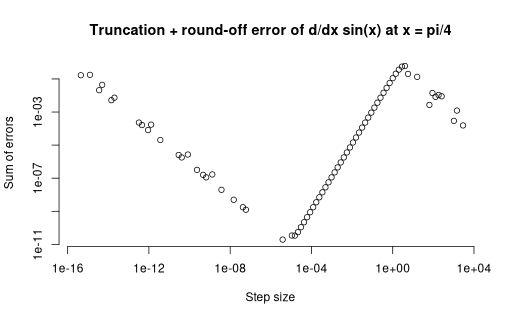

```r
dsin <- function(x, h) (sin(x+h) - sin(x-h)) / h / 2
totErr <- function(x, h, t = 0.5) (dsin(x, t*h) - dsin(x, h)) / (1 - t^2)
hgrid <- 2^seq(-52, 12, 0.5)
suppressWarnings(plot(hgrid, totErr(x = pi/4, hgrid), log = "xy",
     main = "Truncation + round-off error of d/dx sin(x) at x = pi/4",
     bty = "n", xlab = "Step size", ylab = "Sum of errors"))
```

For large step sizes, the total error behaves erratically, and for step sizes $h > h^*$ and $h < 1$, the logarithmic slope is equal to the accuracy order – in this case, $a=2$:

```r
h   <- c(2^-8, 2^-9)
te  <- totErr(x = pi/4, h = h)
print(diff(log(te)) / diff(log(h)))
```

```
#> [1] 1.999999
```

Recommendations:

1. For the initial step size $h_0$, choose a power of 2 to avoid representation errors (step sizes other than $2^j$ are not presentable in binary). This ensures that $[x+h]$ and $[x-h]$ have full precision and both are exactly centred at $x$. The default value in the implementation uses a power of two.
2. For the step-size reduction ratio, choose a power of 2 (e.g. 0.5).

## 1.5 Robust grid search

Mathur (2012) mentions that the Stepleman and Winarsky (1979) algorithms performs reliably when the initial step size $h_0$ is chosen well. The requirements imposed on $h_0$ are the following: it should be large enough for the truncation error to be dominant, but not too large that the estimated truncated error decreases with the step size growth and ceases to be a valid approximation of the true truncation error.

None of the previous algorithms explicitly make use of the parallel capabilities of modern processors. The following improvements can be made for speed gains: * In the Curtis–Reid approach, the function values at $(x-h, x, x+h)$ can be computed im parallel for forward and central differences at each step, which speeds it up by a factor of 3; * In the Dumontet–Vignes approach, the first and third derivatives can be computed in parallel on the symmetric 2-point and 4-point stencils, respectively, which is 2–3 times faster; * The Stepleman–Winarsky algorithm is a sequence of condition checks; the authors remark that the central differences should be computed for at least 3 step sizes, which provides the opportunity for a 6-fold time decrease. * Mathur does not specify the limits for the step-size sequence length to determine the range validity; nevertheless, it is trivial to pre-emptively compute the central differences for multiple sizes because this approach is not slower than the serial version even if the algorithm has to terminate immediately.

Replace Mathur’s counter incrementing with one parallel grid search and find the range where the estimated truncation slope is closest to $a$ – should be faster without any side effects

## 1.6 Not letting intermediate values go to waste

```r
h <- c(1e-4, 1.490116e-07)
b <- c(-h, 0, rev(h)) / min(h)
fc <- fdCoef(deriv.order = 1, stencil = b)
print(fc, 3)
```

```
#> $stencil
#> [1] -671   -1    1  671
#>
#> $weights
#> x-671.09h      x-1h      x+1h x+671.09h
#>  1.65e-09 -5.00e-01  5.00e-01 -1.65e-09
#>
#> attr(,"remainder.coef")
#> [1] -4.61e-12
#> attr(,"accuracy.order")
#> requested effective
#>        NA         3
#> attr(,"expansion")
#> [1] "f ' - 4.6073e-12 f ''' + ..."
```

The optimal weights for the outermost elements of this stencil are tiny ($\approx 1.65\cdot 10^{-9}$). In addition, the `best’ step size is the minimiser of the quantity that depends on the coefficients in the Taylor expansion. The further the evaluation points are away from the Taylor polynomial centre, the higher the coefficients on its terms, which are a power function of $(b_i h)$. Eliminating the terms not related to the derivative on interest requires, as described above as the intuition of the method, solving a system of linear equations, and numerical solvers can be unstable when the input numbers are huge. As a consequence, the suggested weights $w_i$ may suffer from ill conditioning of the matrix of the Taylor polynomial coefficients that take large values far away from the centre.

This raises the question: how accurate is this four-term weighted sum where two weights are tiny?

```r
cos(1) - sum(sin(1 + fc$stencil * h[2]) * fc$weights) / h[2]
```

```
#> [1] 1.040656e-09
```

This simulation aims to determine the behaviour of the absolute approximation error under difference step-size selection rules and weigh the pros and cons of extra grid points that are far away.

!!! TODO: add fast functions like sin(1000*x) or slow like log(x) at x = 13 – and check the convergence radius

```r
hOpt <- function(x) (1.5 * abs(tan(x)) * .Machine$double.eps)^(1/3)

set.seed(1)
xgrid <- sort(runif(10000, max = 2*pi))
hgrid <- hOpt(xgrid)
df1 <- (sin(xgrid + hgrid) - sin(xgrid - hgrid)) / hgrid / 2
df2 <- (sin(xgrid + 7e-6) - sin(xgrid - 7e-6)) / 7e-6 / 2
fc  <- fdCoef(deriv.order = 1, stencil = c(-500, -1, 1, 500))
h4grid <- outer(hgrid, c(-500, -1, 1, 500))
df4 <- rowSums(sweep(sin(xgrid + h4grid), 2, fc$weights, "*")) / hgrid
df.true <- cos(xgrid)
err <- df.true - data.frame(df1, df2, df4)
abserr <- abs(err)

print(summary(err))
```

```
#>       df1                  df2                  df4
#>  Min.   :-5.990e-10   Min.   :-1.167e-11   Min.   :-5.991e-10
#>  1st Qu.:-8.680e-12   1st Qu.:-1.960e-12   1st Qu.:-6.979e-12
#>  Median : 1.088e-12   Median : 2.441e-12   Median :-3.963e-14
#>  Mean   : 4.594e-14   Mean   : 2.013e-12   Mean   : 3.846e-14
#>  3rd Qu.: 8.156e-12   3rd Qu.: 5.335e-12   3rd Qu.: 7.403e-12
#>  Max.   : 5.076e-10   Max.   : 1.685e-11   Max.   : 5.076e-10
```

```r
print(summary(abserr))
```

```
#>       df1                 df2                 df4
#>  Min.   :6.440e-15   Min.   :2.220e-16   Min.   :4.900e-16
#>  1st Qu.:3.484e-12   1st Qu.:2.226e-12   1st Qu.:2.388e-12
#>  Median :8.320e-12   Median :4.263e-12   Median :7.164e-12
#>  Mean   :1.667e-11   Mean   :4.463e-12   Mean   :1.589e-11
#>  3rd Qu.:2.132e-11   3rd Qu.:5.990e-12   3rd Qu.:2.063e-11
#>  Max.   :5.990e-10   Max.   :1.685e-11   Max.   :5.991e-10
```

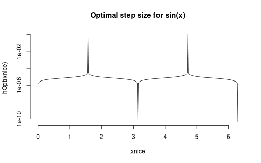

```r
squish <- function(x, pow = 1/6, shift = 1e-12) ((abs(x) + shift)^pow - shift^pow) * sign(x)
xnice <- seq(0, 2*pi, length.out = 401)
plot(xnice, hOpt(xnice), type = "l", log = "y", main = "Optimal step size for sin(x)", bty = "n")
```

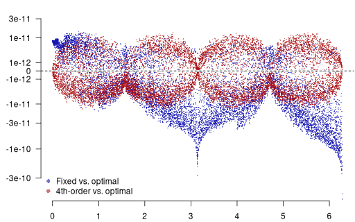

```r
par(mar = c(2, 4, 0, 0) + .1)
matplot(xgrid, squish(abserr[, 2:3] - abserr[, 1]), type = "p", bty = "n",
        xlab = "", ylab = "", ylim = squish(c(-5e-10, 5e-11)), yaxt = "n",
        col = c("#0000AA88", "#AA000088"), pch = 16, cex = 0.3)
abline(h = 0, lwd = 3, col = "white")
abline(h = 0, lty = 2)
legend("bottomleft", c("Fixed vs. optimal", "4th-order vs. optimal"), bty = "n", pch = 16, col = c("#00008888", "#88000088"))
yax.vals <- c(-3e-10, -1e-10, -3e-11, -1e-11, -1e-12, 0, 1e-12, 1e-11, 3e-11)
axis(2, squish(yax.vals), yax.vals, las = 1)
```

The reader is invited to experiment with other function, other argument ranges, and other stencils with large and small gaps produce by more drastic step changes in iterations.

During numerical optimisation, drop, do not store

Near the optimum, store

# 2 Non-uniform grid spacing

So far, only uniform spacing for second-order-accurate numerical approximation of $f'(x)$ has been concerned. However, in many situations, higher-order accuracy is required, e.g. in computing Hessians for subsequent inversion to obtain asymptotic variance for statistical inference. Usually, uniform grids of the form $\{x_0, x_0\pm h, x_0\pm2h, x_0\pm3h, \ldots\}$ or $\{x_0\pm h, x_0\pm3h, x_0\pm5h, \ldots\}$ are used to evaluate $f$ and obtain an interpolating polynomial of the desired degree. Nevertheless, the choice of uniform grids is mostly a historical artefact rather than a modelling choice.

## 2.1 First-order derivatives

Oliver and Ruffhead (1975) proposed a method of selection of interpolation points on a non-uniform grid for first derivatives, and Oliver (1980) extended it to second and third derivatives. It is, indeed, not clear, which grid is better for fourth-order derivatives: $\{-3, -1, 1, 3\}$, $\{-2, -1, 1, 2\}$, or $\{-1.01, -1, 1, 1.01\}$. On one hand, shrinking the step size reduces numerical error; on the other hand, if $\pm h$ if contaminated by a certain level of rounding noise, then, $\pm 1.01 h$ does not seem ample enough to reduce the effect of the machine-related error. Therefore, there should be a trade-off between the truncation and rounding error as a non-trivial function of the grid spacing magnitude.

**Problem.** Given the desired accuracy order of a first derivative, find the optimal symmetric grid $x_0 \pm h, x_0 \pm c_1 h, x_0 \pm c_2 h$, $1 < c_1 < c_2 < \ldots$ for finite differencing to minimise the expected combined rounding and truncation errors.

**Solution.** There are many mathematically equivalent ways of writing down the derivative $f'(x_0)$ as the derivative of an approximating polynomial. Earlier authors, e.g. Rutishauser (1963) deemed that the most convenient approach, due to its simplicity, is Romberg-like iterative extrapolation. Modern textbooks, like Sauer (2017), prefer deriving the total error by bounding Fornberg sums.

Firstly, assume that the first two grid points are $x \pm h$, and the task consists in finding the scaling factors $1 < c_1, c_2, \ldots$ for $h$ to obtain the optimal grid. As in previous analyses, it is somewhat impractical to minimise the sum of two errors $|\varepsilon_{\mathrm{t}}| + \varepsilon_{\mathrm{r}}|$ directly as $\varepsilon_{\mathrm{t}}(h) = \frac{f^{d+a}(\xi)}{6}h^{a}$ ($\alpha\in[-1, 1]$) is not observed directly. (Note that $\xi = x + \alpha h$, $\alpha \in [0, 1]$ for $f'_{\mathrm{CD}}(x_0)$, but this is not true for higher-order derivatives due to the fact that the Generalised Intermediate Value Theorem yields more than one term.)

To shorten notation for the grid around the point of interest $x_0$, denote $x_{2i-1} = x_0 + c_i h$, $x_{2i} = x_0 - c_i h$, $i = 1, \ldots, a/2$, so $\{x_0, \ldots, x_n\}$ becomes the full evaluation grid.

It is possible to make two observations:

1. If the truncation error is valid, then, it is proportional to $(x_0 - x_1)\cdots(x_0 - x_n) / (n+1)! f^{d+a}(\xi)$;
2. Moving $c_1$ closer to unity reduced the truncation error but increases the rounding error $|R| \le M\cdot E$ by a magnitude factor
   $$M = \sum_{i=1}^n |L'_i(x_0)|, \quad E = \max\{|\varepsilon_i|, \quad
   i = 1, \ldots, n\},$$
   where $L_i$’s are the Lagrange basis polynomials and $\epsilon_i := f(x_i) - \hat f(x_i)$ is the individual rounding error.

To remove the dependence of $\xi$ on $\{x_1, \ldots, x_n\}$, assume that $f^{(d+a)}(x)$ is relatively constant over the interval containing the points $x_1,\ldots, x_n$ – require that $\Psi = (x_0 - x_1) \cdots (x_0 - x_n)$ is constant. Then, the scaling factor for the error is equal to
$$S = M \sqrt[n]{\Psi} = (c_1 \dots c_{n/2})^{2/n} \sum_{i=1}^{n/2}
\left|c_i^{-1} \prod_{j\ne i}^{n/2} \frac{r_j^2}{r_j^2 - r_i^2} \right|$$

Now we implement this objective function in R and minimise it.

```r
S <- function(r) {
  if (is.unsorted(r)) r <- sort(r)
  n_2 <- length(r)
  n <- length(r) * 2
  s <- numeric(n_2)
  for (k in 1:n_2) {
    j <- setdiff(1:n_2, k)
    s[k] <- prod(abs(r[j]^2 / (r[k]^2 - r[j]^2))) / r[k]
  }
  prod(r)^(1/n_2) * sum(s)
}
```

At first, we can establish that $(-2, -1, 1, 2)$ is marginally inferior to $(-3, -1, 1, 3)$:

```r
S(c(1, 2))
```

```
#> [1] 2.12132
```

```r
S(c(1, 3))    # Better
```

```
#> [1] 2.020726
```

```r
S(c(1, 2.6))  # Even better
```

```
#> [1] 2.00006
```

Here is how the curve looks for a 4-point grid, suggesting that the optimal $c_1 \approx 2.6$:

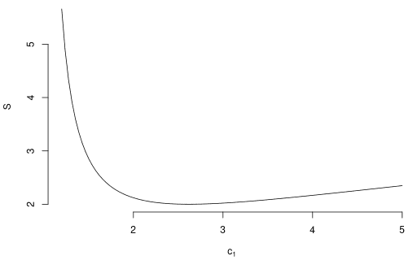

```r
ff <- Vectorize(function(x) S(c(1, x)))
oldpar <- par(mar = c(4, 4, 0, 0) + .1)
curve(ff, 1.2, 5, bty = "n", xlab = expression(c[1]), ylab = "S")
```

```r
optim(par = 2, fn = ff, method = "BFGS")$par
```

```
#> [1] 2.618034
```

```r
# THE optimal length-4 grid is x0 + (-2.62, -1, 1, 2.62)h

# Finding the optimum for multiple lengths
nn <- 9
res <- vector("list", nn)
for (i in seq_along(res)) {
  set.seed(i)
  n <- 2 + 2*i
  # init.val <- (1:i)*2
  ff <- function(x) S(c(1, x))
  lower <- 1:i
  upper <- (1+(1:i)*3)^0.9
  init.pop <- sapply(1:i, function(j) runif(n*20, lower[j], upper[j]))
  init.pop <- apply(init.pop, 1, sort)
  if (NCOL(init.pop) == 1) init.pop <- matrix(init.pop) else
    if (ncol(init.pop) > nrow(init.pop)) init.pop <- t(init.pop)
  ff0 <- apply(init.pop, 1, ff)
  x0 <- init.pop[which.min(ff0), ]
  res[[i]] <- sort(optim(par = x0, fn = ff, method = "BFGS",
                         control = list(reltol = 1e-8, maxit = 100))$par)
}

# Table 2b from Oliver & Ruffhead (1975)
tab <- matrix(nrow = length(res), ncol = nn)
for (i in 1:nn) tab[i, 1:i] <- res[[i]]
```

If one needs to devise a fixed-size grid, collapsing a triangular array into a one-size-fits-all may also be useful.

```r
bmean <- round(colMeans(tab, na.rm = TRUE), 2)
print(bmean)
```

```
#> [1]  2.89  4.64  6.25  7.73  9.07 10.29 11.39 12.36 13.23
```

```r
ff(bmean)  # Close to 10
```

```
#> [1] 10.06956
```

```r
ff(bmean[1])  # Close to 2
```

```
#> [1] 2.011236
```

The optimal sequences can be visualised, which reveals the shrinkage of two subsequent points, implying that $c_{i+1} - c_{i} < c_{i} - c_{i-1}$ and $c_{i+1}/c_i < c_i / c_{i-1}$.

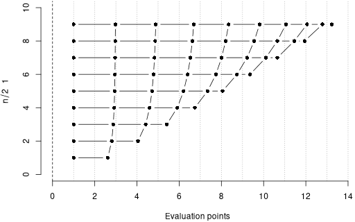

```r
par(mar = c(4, 4, 0, 0) + .1)
plot(NULL, NULL, xlim = c(0, max(res[[i]]) + .5), ylim = c(0, nn+1),
     xlab = "Evaluation points", ylab = expression(n/2-1), bty = "n")
for (i in 1:9) points(c(1, res[[i]]), rep(i, length(res[[i]])+1), pch = 16, type = "b")
for (i in 1:9) points(sapply(res, "[", i), rep(1:nn), pch = 16, type = "b")
abline(v = 0, lty = 2)
abline(v = seq(1, max(bmean)+1), lty = 3, col = "#00000044")
```

Finally, the near-optimal sequence of points can be generated by the estimated non-linear relationship $c_{i-1} \approx -4.37 + 5.03 i^{0.55}$ for $i = 2, \ldots, n/2$:

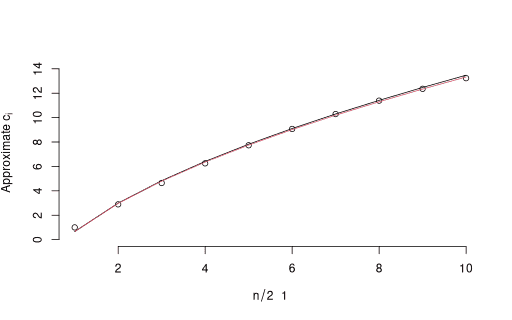

```r
b <- c(1, bmean)  # Nodes
x <- 1:10
plot(x, b, bty = "n", xlab = expression(n/2-1), ylim = c(0, max(bmean)+1),
     ylab = expression("Approximate"~c[i]))
ft <- nls(b ~ d + c*x^a, start = c(d = 0, c = 2.5, a = 0.75), weights = 1:10)
lines(x, -4.37 + 5.03 * x^0.55)
lines(x, predict(ft), col = 2)
```

```r
par(oldpar)
```

# 3 References

Curtis, A. R., and J. K. Reid. 1974. “The Choice of Step Lengths When Using Differences to Approximate Jacobian Matrices.” *IMA Journal of Applied Mathematics* 13 (1): 121–26. https://doi.org/10.1093/imamat/13.1.121.

Dumontet, J., and J. Vignes. 1977. “Détermination Du Pas Optimal Dans Le Calcul Des Dérivées Sur Ordinateur.” *RAIRO. Analyse Numérique* 11 (1): 13–25. https://doi.org/10.1051/m2an/1977110100131.

Mathur, Ravishankar. 2012. “An Analytical Approach to Computing Step Sizes for Finite-Difference Derivatives.” PhD thesis, University of Texas at Austin. http://hdl.handle.net/2152/ETD-UT-2012-05-5275.

———. 2013. “Algorithm AAS 13-723: An Analytical Approach to Computing Step Sizes for Finite-Difference Derivatives.” Emergent Space Technologies, Inc. https://web.archive.org/web/20240527044243/https://www.emergentspace.com/wp-content/uploads/stepsize.pdf.

Oliver, John. 1980. “The Selection of Interpolation Points in the Numerical Approximation of Second and Third Order Derivatives.” *Journal of Computational and Applied Mathematics* 6 (3): 229–39. https://doi.org/10.1016/0771-050x(80)90030-3.

Oliver, John, and Andrew Ruffhead. 1975. “The Selection of Interpolation Points in Numerical Differentiation.” *BIT Numerical Mathematics* 15 (3): 283–95. https://doi.org/10.1007/BF01933661.

Rutishauser, H. 1963. “Ausdehnung Des Rombergschen Prinzips.” *Numerische Mathematik* 5 (1): 48–54. https://doi.org/10.1007/BF01385877.

Sauer, Timothy. 2017. *Numerical Analysis*. 3rd ed. Pearson Education.

Stepleman, R. S., and N. D. Winarsky. 1979. “Adaptive Numerical Differentiation.” *Mathematics of Computation* 33 (148): 1257–64. https://doi.org/10.1090/s0025-5718-1979-0537969-8.